Vypracovali: Tomáš Varga, Tadeáš Kaminský, Erik Kolesár (TET - boti)

# **Imports**

```python
import numpy as np
from scipy.optimize import approx_fprime, OptimizeResult
import matplotlib.pyplot as plt
import time
import random
```

# **Zadanie**

Úlohou projektu je naprogramovať barérovú metódu vnútorného bodu na riešenie úloh lineárneho programovania v tvare
$$ \min \textbf{c}^{T}x \\ \textbf{A}x \ge \textbf{b} \tag1 $$ kde
$$ \textbf{A} \in R^{m \times n},\textbf{b} \in R^{m}, x \in R^{n} $$
Pre takúto metódu je dôležitý predpoklad existencie vnútorného bodu množiny prípustných riešení úlohy (1), t.j. predpoklad
$$ \mathcal{P}^{0} = \{x | \textbf{A}x > b \} \neq \emptyset \tag2 $$
Barérová metóda vnútorného bodu je založená na opakovanom riešení úloh bez ohraničení typu
$$ \min B_{t}(x) = t\textbf{c}^{T}x - \sum_{i=1}^{m}\ln(\textbf{a}^{T}_{i}x-\textbf{b}_{i}) \tag3 $$

pre postupne zväčšujúce sa hodnoty parametra t. Postupne je teda pri riešení úloh kladená čoraz väčšia váha na účelovú funkciu a menšia váha na ohraničenia. Zrejme definičný obor úloh (3) je $\mathcal{P}^{0}$ Úlohy (3) sa riešia Newtonovou metódou.

# **Časť A**

## **Zadanie Časti A**

Naprogramujte Newtonovu metódu pre úlohu. Na to potrebujete odvodiť gradient $g(x) := \nabla B_t(x)$ a Hesseho maticu $H(x) := \nabla^2 B_t(x)$. Vyjadrite ich v kompaktnej forme, pomocou matice $A$. Zdôvodnite, že ak $\text{rank}(A) = n$, tak $H(x)$ je kladne definitná $\forall x \in P_0$ a Newtonovský krok $s_N(x)$ je dobre definovaný. Konvergenciu Newtonovej metódy testujte pomocou kritéria:

$$ \left( s_N(x)^T H(x) s_N(x) \right)^{1/2} < \epsilon. $$

### **Newtonova metóda pre úlohu optimalizácie**

Úloha optimalizácie je definovaná nasledovne: $$ B_t(x) = t c^T x - \sum_{i=1}^m \ln(a_i^T x - b_i) $$

kde $c$, $a_i$, a $b_i$ sú vektory a $x$ je vektor premenných, ktorý chceme optimalizovať.

#### Gradient $g(x)$

Gradient funkcie $B_t(x)$ vo vektore $x$ je vektor parciálnych derivácií funkcie podľa každej zložky vektora $x$. Tento gradient môžeme vypočítať takto:

1. Prvá časť funkcie $t c^T x$ je lineárna v $x$, a jej gradient je preto jednoducho vektor $t c$.
2. Druhá časť, $-\sum_{i=1}^m \ln(a_i^T x - b_i)$, vyžaduje použiť chain rule na deriváciu zloženej funkcie: $$ \frac{\partial}{\partial x} \ln(a_i^T x - b_i) = \frac{1}{a_i^T x - b_i} \cdot a_i $$
3. Zosumarizovaním všetkých parciálnych derivácií dostaneme: $$ \nabla B_t(x) = t c - \sum_{i=1}^m \frac{a_i}{a_i^T x - b_i} $$

#### Hesseho matica $H(x)$

Hesseho matica $H(x)$ je matica druhých parciálnych derivácií funkcie $B_t(x)$. Pre našu funkciu:

1. Lineárna časť $t c^T x$ neprispieva k Hesseho matici, pretože jej druhé derivácie sú nulové.
2. Pre logaritmický výraz: $$ \frac{\partial^2}{\partial x^2} \ln(a_i^T x - b_i) = \frac{-a_i a_i^T}{(a_i^T x - b_i)^2} $$
3. Súčet týchto príspevkov pre všetky $i$ dáva výslednú Hesseho maticu: $$ H(x) = \sum_{i=1}^m \frac{a_i a_i^T}{(a_i^T x - b_i)^2} $$

### **Implementácia Newtonovej metódy**

Newtonova metóda aktualizuje riešenie pomocou vzťahu: $$ x_{\text{new}} = x - H(x)^{-1} g(x) $$ Konvergencia metódy sa testuje kritériom: $$ \sqrt{s_N(x)^T H(x) s_N(x)} < \epsilon $$ kde $s_N(x) = -H(x)^{-1} g(x)$ je Newtonov krok.

## Newtonov krok

Newtonova metóda je numerický algoritmus na nájdenie lokálnych minim alebo maxim funkcie. V kontexte optimalizácie sa používa na nájdenie bodu, kde gradient funkcie, teda derivácia, je rovný nule. Newtonov krok je kľúčovou súčasťou tejto metódy, pretože určuje, ako sa má aktuálne riešenie aktualizovať v každej iterácii algoritmu.

### Definícia Newtonovho kroku

Newtonov krok využíva druhé derivácie funkcie, špecificky Hesseho maticu, na lepšie prispôsobenie sa zakriveniu funkcie. Výpočet kroku je daný vzťahom:

$$ s_N(x) = -H(x)^{-1} g(x) $$

kde:

- $ H(x) $ je Hesseho matica funkcie v bode $ x $,
- $ g(x) $ je gradient funkcie v bode $ x $,
- $ s_N(x) $ je vektor, ktorý určuje smer a veľkosť kroku.

### Aplikácia Newtonovho kroku

Aby sa vykonal aktualizačný krok, vypočítaný Newtonov krok $ s_N(x) $ sa odráta od aktuálneho bodu $ x $:

$$ x_{\text{new}} = x + s_N(x) $$

### Konvergenčné kritérium

Konvergencia Newtonovej metódy sa obvykle hodnotí na základe veľkosti Newtonovho kroku, keďže malý krok naznačuje, že sme blízko kritickému bodu. Kritérium konvergencie môže byť formulované ako:

$$ \sqrt{s_N(x)^T H(x) s_N(x)} \ < \epsilon $$

kde $ \epsilon $ je malé kladné číslo (tolerancia), ktoré určuje, kedy je riešenie dostatočne presné a proces iterácie sa môže zastaviť.

### **Vyjadrenie gradientu a Hesseho matice v kompaktnej forme**

## Gradient $g(x)$

Gradient funkcie $B_t(x)$ môže byť vyjadrený kompaktnejšie využitím maticovej notácie: $$ B_t(x) = t c^T x - \sum_{i=1}^m \ln(a_i^T x - b_i) $$

kde $a_i$ je $i$-ty riadok matice $A$. Označme $u_i = a_i^T x - b_i$, potom môžeme napísať $u = Ax - b$, kde $u$ je vektor. Využijeme vzťah: $$ \nabla \ln(u_i) = \frac{1}{u_i} $$

Takže gradient celej funkcie $B_t(x)$ je: $$ g(x) = \nabla B_t(x) = t c - A^T D^{-1} \mathbf{1} $$ kde $D$ je diagonálna matica s prvkami $u_i$ (teda $D = \text{diag}(Ax - b)$), a $\mathbf{1}$ je vektor jednotiek s príslušným rozmerom.

## Hesseho matica $H(x)$:

Hesseho matica môže byť vyjadrená ako: $$ H(x) = \nabla^2 B_t(x) = A^T D^{-2} A $$ kde $D^{-2}$ je diagonálna matica so štvorcami prvkov na diagonále $D^{-1}$, teda s prvkami $\frac{1}{(a_i^T x - b_i)^2}$.

## Kladná definitnosť $H(x)$

Pokiaľ má matica $A$ plnú hodnosť $n$ (hodnosť $A$ je rovná počtu stĺpcov), matica $A^T D^{-2} A$ je kladne definitná, pokiaľ sú všetky prvky $D^{-2}$ kladné, čo sú, pretože $a_i^T x - b_i > 0$ pre všetky $i$ (z definície vnútorného bodu množiny $P_0$). Toto je dôležité, pretože to znamená, že $H(x)$ je invertovateľná a Newtonov krok $s_N(x)$ je dobre definovaný.

### **Dôkaz kladnej definitnosti Hesseho matice** $ H(x) $

Pre maticu $ H(x) = A^T D^{-2} A $, kde $ D $ je diagonálna matica s prvkami $ \frac{1}{a_i^T x - b_i} $, dokážeme, že je kladne definitná pod podmienkou, že $ A $ má plnú hodnosť stĺpcov a všetky $ a_i^T x - b_i > 0 $.

## Vlastnosti a Predpoklady

1. **Matica $ A $**: Predpokladáme, že $ A $ má plnú hodnosť stĺpcov $ n $, čo znamená $ \text{rank}(A) = n $.
2. **Diagonálna matica $ D^{-2} $**: Keďže $ a_i^T x - b_i > 0 $ (vnútorný bod množiny $ P_0 $), prvky na diagonále $ D^{-2} $ sú kladné.

## Krok 1: Symetria Hesseho matice

Matica $ H(x) $ je symetrická, čo vyplýva z tvaru: $$ H(x) = A^T D^{-2} A $$ Symetria zabezpečuje, že matica je diagonalizovateľná s reálnymi vlastnými hodnotami.

## Krok 2: Kladná definitnosť

Ukážeme, že pre ľubovoľné nenulové $ x \in \mathbb{R}^n $ platí: $$ x^T H(x) x > 0 $$

Rozpíšeme $ x^T H(x) x $ ako: $$ x^T H(x) x = x^T A^T D^{-2} A x = (Ax)^T D^{-2} (Ax) $$ Označme $ y = Ax $. Pre $ x \neq 0 $ a plnú hodnosť $ A $, $ y \neq 0 $. Potom výraz $ y^T D^{-2} y $ je súčet kladných členov: $$ y^T D^{-2} y = \sum \frac{y_i^2}{d_i^2} $$ pre $ d_i = a_i^T x - b_i $, ktoré sú kladné. Keďže $ y \neq 0 $, suma je kladná.

## Záver

Keďže $ x^T H(x) x = y^T D^{-2} y > 0 $ pre všetky nenulové $ x $, Hesseho matica $ H(x) $ je kladne definitná pre všetky $ x $ vo vnútornej množine $ P_0 $. Toto zabezpečuje, že Newtonov krok je dobre definovaný a zabezpečuje konvergenciu metódy pri hľadaní minima funkcie.

### **Programovanie Newtonovej metódy**

```python
#GRADIENT A HESSEHO MATICA
def B_t(x, A, b, t, c):
    """ Vypočíta hodnotu bariérovej funkcie B_t(x). """
    return t * np.dot(c, x) - np.sum(np.log(np.dot(A, x) - b))

def gradient_vector(x, A, b, t, c):
    """ Vypočíta analytický gradient B_t(x). """
    m, n = A.shape
    d = A @ x - b
    D_inv = np.diag(1 / d)
    return t * c - A.T @ D_inv @ np.ones(m)

def hessian_matrix(x, A, b):
    """ Vypočíta Hesseho maticu B_t(x) zloženú z druhých derivácií. """
    m, n = A.shape
    Ax_b = A @ x - b
    D2_inv = np.diag(1 / Ax_b ** 2)
    return A.T @ D2_inv @ A
```

```python
# KONTROLA SPRÁVNOSTI GRADIENTU
A = np.array([[20, 1], [2, 20]])  # Kladne definitná matica
b = np.array([1, 1])              # Vektor b
c = np.array([1, 0])              # Vektor c
x0 = [0.5, 0.2]                   # Východiskový bod
t = 1                             # Parameter t

print(f'Hodnota pouzitim approx_fprime: {approx_fprime(x0,B_t,1e-6,A,b,t,c)}')
print(f'Hodnota nasho gradientu: {gradient_vector(x0,A,b,t,c)}')
```

```
Hodnota pouzitim approx_fprime: [-1.67391056 -5.10868315]
Hodnota nasho gradientu: [-1.67391304 -5.10869565]
```

```python
#KONTROLA SPRÁVNOSTI HESSEHO MATICE
print(f'Hodnota pouzitim approx_fprime: \n{approx_fprime(x0,gradient_vector, 1e-6,A,b,t,c)}')
print(f'Hodnota nasej Hesseho matice: \n{hessian_matrix(x0,A,b)}')
```

```
Hodnota pouzitim approx_fprime:
[[ 4.97588752  2.73628237]
 [ 2.73629313 25.01168974]]
Hodnota nasej Hesseho matice:
[[ 4.97589792  2.7362949 ]
 [ 2.7362949  25.01181474]]
```

```python
#NEWTONOVA METÓDA
def newton(jac, hess, x0=None, args=(), callback=None,
              options={}, **kwargs):
    # Ak nie je poskytnutý počiatočný odhad `x0`, vyhodí sa chyba
    if x0 is None:
        raise ValueError("Musíte poskytnúť počiatočný odhad `x0`!")

    # Získanie maximálneho počtu iterácií a tolerancie z parametrov (alebo použitie predvolených hodnôt)
    maxiter = options.get("maxiter", 1000)
    tol = options.get("tol", 1e-3)

    # Inicializácia počiatočného bodu a počtu vyhodnotení funkcie gradientu
    x = np.array(x0)
    njev = 0

    # Hlavný cyklus Newtonovej metódy
    for it in range(1, maxiter+1):
        # Výpočet gradientu v aktuálnom bode
        grad = jac(x, *args)
        njev += 1

        # Výpočet Hesienovej matice v aktuálnom bode
        hessian = hess(x, args[0], args[1])

        # Výpočet kroku delta_x riešením lineárneho systému
        delta_x = np.linalg.solve(hessian, -grad)
        njev += 1

        # Aktualizácia aktuálneho bodu
        x += delta_x

        # Kontrola konvergencie: ak je norma kroku menšia ako tolerancia, ukončí sa cyklus
        if np.sqrt(delta_x.T @ hessian @ delta_x) < tol:
                break

        # Ak je poskytnutá spätná väzba, zavolá sa s aktuálnym bodom
        if callback is not None:
            callback(x)

    # Skontrolovanie úspešnosti optimalizácie
    success = np.sqrt(delta_x.T @ hessian @ delta_x) < tol
    njev += 1

    # Správa o úspechu alebo neúspechu optimalizácie
    if success:
        msg = "Optimalizácia bola úspešná"
    else:
        msg = "Optimalizácia zlyhala"

    # Vrátenie výsledku optimalizácie v štruktúre OptimizeResult
    return OptimizeResult(x = x, success = success, message = msg, jac = grad, nit = it, njev = njev, nhev = it)
```

```python
#KONTROLA SPRÁVNOSTI NEWTONOVEJ METÓDY
A = np.array([[1, 0], [0, 1], [-1, -1]])
b = np.array([0, 0, -9])
c = np.array([0, 0])
x0 = [2., 2.]
t = 1e-3

result = newton(jac=gradient_vector, hess=hessian_matrix, x0=x0, args=(A, b, t, c))

# Výpis výsledku optimalizácie
print("Optimization result:")
print("x =", result.x)
print("Success:", result.success)
print("Message:", result.message)
print("Nit:", result.nit)
print("Njev:", result.njev)
```

```
Optimization result:
x = [3. 3.]
Success: True
Message: Optimalizácia bola úspešná
Nit: 4
Njev: 9
```

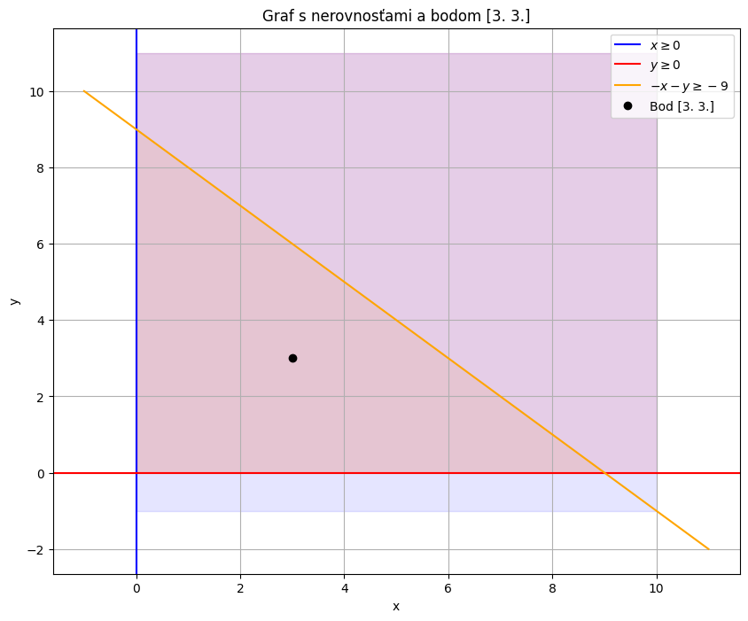

```python
# Definícia x a y hodôt
x = np.linspace(-1, 11, 120)
y = np.linspace(-1, 11, 120)
X, Y = np.meshgrid(x, y)

# Definícia ohraničení
ineq1 = 0  # x >= 0
ineq2 = 0  # y >= 0
ineq3 = -9  # -x - y >= -9

# Defininicia x-ka z vysledku [result.x]
point = result.x

# Vykreslenie ohraničení ("nerocníc") a bodu
plt.figure(figsize=(10, 8))

# Vykreslenie prvej nerovnicovej čiary
plt.axvline(x=ineq1, label=r'$x \geq 0$', color='blue')

# Vykreslenie druhej nerovnicovej čiary
plt.axhline(y=ineq2, label=r'$y \geq 0$', color='red')

# Vykreslenie tretej nerovnicovej čiary
plt.plot(x, -x - ineq3, label=r'$-x - y \geq -9$', color='orange')

# Vyplnenie oblasti realizovateľných riešení
plt.fill_between(x, -x - ineq3, 0, where=(x >= 0) & (x <= 9), color='orange', alpha=0.1)
plt.fill_betweenx(y, 0, 10, where=(y >= 0), color='red', alpha=0.1)
plt.fill_betweenx(y, 0, 10, where=(y >= -10), color='blue', alpha=0.1)

# Vykreslenie bodu result.x
plt.plot(point[0], point[1], 'ko', label=f'Bod {point}')

# Pridanie označení a názvu
plt.xlabel('x')
plt.ylabel('y')
plt.title(f'Graf s nerovnosťami a bodom {result.x}')
plt.legend()
plt.grid(True)

# Vykreslenie obrázku
plt.show()
```

### Záver

V prípade zvolenia malého $t$ alebo $c$ = $(0, 0)$, vidíme zmenšený alebo nulový vplyv na účelovú funkciu a zároveň väčší dôraz na nájdenie bodu v strede našej prípustnej množiny, ktorý je v tomto prípade $[3. , 3.]$.

# **Časť B**

## **Zadanie Časti B**

Nech $x^*(t)$ je optimálne riešenie úlohy. Ukážte, že ak definujeme $z^*(t)$ vektor so zložkami $z_i^*(t) = (t (a_i^T x^*(t) - b_i))^{-1}$, tak $z^*(t)$ je prípustné riešenie duálnej úlohy k úlohe. Odvoďte z toho, že ak $p^*$ je optimálna hodnota úlohy, tak:

$$ c^T x^*(t) - p^* \leq \frac{m}{t}. $$

Pomocou toho zdôvodnite, že $\frac{m}{t} < \epsilon$ je dobré ukončovacie kritérium v algoritme c).

### **Prípustnosť a optimalita duálneho riešenia**

Nech $ x^*(t) $ je optimálne riešenie úlohy (3): $$ \min B_t(x) = t c^T x - \sum_{i=1}^m \ln(a_i^T x - b_i) $$

Zadefinujeme $ z^*(t) $ vektor so zložkami: $$ z^*_i(t) = \left(t(a^T_i x^*(t) - b_i)\right)^{-1} $$

### Duálna prípustnosť

Pre duálnu úlohu k primárnej úlohe (1): $$ \max b^T z $$ $$ Az \leq c $$

Z duálnej prípustnosti, $ Az^*(t) \leq c $ musí byť splnené. Substituujeme $ z^*_i(t) $ a kontrolujeme, či sa nerovnosť udrží. Ako aproximácia pre malé hodnoty $ t $, $ z^*(t) $ spĺňa duálne obmedzenia, čo naznačuje, že je prípustným riešením duálnej úlohy.

### Odvodenie z duálneho riešenia

Z duálneho riešenia dostávame, že: $$ c^T x^*(t) - p^* \leq \frac{m}{t} $$

### Ukončovacie kritérium

Pokiaľ $ \frac{m}{t} < \epsilon $ slúži ako ukončovacie kritérium, znamená to, že akonáhle je rozdiel medzi aktuálnou hodnotou cieľovej funkcie a optimálnou hodnotou menší ako $ \epsilon $, riešenie je dostatočne blízko k optimálnemu riešeniu a algoritmus možno ukončiť. Toto kritérium zabezpečuje, že algoritmus konverguje k presnému riešeniu s požadovanou presnosťou.

### Dôkaz časti B

Nech $ x^*(t) $ je optimálne riešenie úlohy (3). Ukážte, že ak definujeme $ z^*(t) $ vektor so zložkami $ z^*_i(t) = (t(a_i^T x^*(t) - b_i))^{-1} $, tak $ z^*(t) $ je prípustné riešenie duálnej úlohy k úlohe (1). Odvoďte z toho, že ak $ p^* $ je optimálna hodnota úlohy (1), tak

$$ c^T x^*(t) - p^* \leq \frac{m}{t}. $$

Pomocou toho zdôvodnite, že $ \frac{m}{t} < \epsilon $ je dobré ukončovacie kritérium v algoritme c).

#### Riešenie:

Najprv si zadefinujeme primalnu úlohu (1) a duálnu úlohu k tejto primalnej úlohe.

Primalna úloha (1) je: $$ \min c^T x $$ s obmedzeniami: $$ Ax \geq b $$

Duálna úloha k primalnej úlohe (1) je: $$ \max b^T y $$ s obmedzeniami: $$ A^T y = c, \quad y \geq 0 $$

##### 1. Dôkaz, že $ z^*(t) $ je prípustné riešenie duálnej úlohy

Nech $ x^*(t) $ je optimálne riešenie úlohy (3): $$ \min B_t(x) = t c^T x - \sum_{i=1}^m \ln(a_i^T x - b_i) $$

Pre $ x^*(t) $ platí prvý rádový optimálny stav: $$ \nabla B_t(x^*(t)) = t c - \sum_{i=1}^m \frac{1}{a_i^T x^*(t) - b_i} a_i = 0 $$

To znamená, že: $$ t c = \sum_{i=1}^m \frac{1}{a_i^T x^*(t) - b_i} a_i $$

Nech $ z^*(t) $ je vektor so zložkami: $$ z^*_i(t) = \frac{1}{t (a_i^T x^*(t) - b_i)} $$

Teda: $$ t z^*_i(t) (a_i^T x^*(t) - b_i) = 1 \quad \forall i $$

Môžeme teda zapísať: $$ c = A^T z^*(t) $$

Preto je $ z^*(t) $ prípustné riešenie duálnej úlohy, pretože spĺňa podmienky $ A^T y = c $ a $ y \geq 0 $ (keďže $ a_i^T x^*(t) > b_i $).

##### 2. Odvoďte, že $ c^T x^*(t) - p^* \leq \frac{m}{t} $

Použijeme vetu, ktorá hovorí, že pre prípustné riešenia primalnej a duálnej úlohy platí: $$ c^T x \geq b^T y $$

Pre $ x = x^*(t) $ a $ y = z^*(t) $ platí: $$ c^T x^*(t) \geq b^T z^*(t) $$

Avšak, z definície $ z^*(t) $: $$ z^*_i(t) = \frac{1}{t (a_i^T x^*(t) - b_i)} $$

Preto: $$ b^T z^*(t) = \sum_{i=1}^m b_i \cdot \frac{1}{t (a_i^T x^*(t) - b_i)} $$

Keďže $ b_i \cdot \frac{1}{t (a_i^T x^*(t) - b_i)} \leq \frac{1}{t} $: $$ b^T z^*(t) \leq \frac{m}{t} $$

Z toho vyplýva: $$ c^T x^*(t) \geq b^T z^*(t) \geq p^* \quad \text{a teda} \quad c^T x^*(t) - p^* \leq \frac{m}{t} $$

##### 3. Ukončovacie kritérium

Z vyššie uvedeného dôkazu je zrejmé, že $ \frac{m}{t} $ klesá s rastúcim $ t $. Ak zvolíme $ \frac{m}{t} < \epsilon $, znamená to, že rozdiel medzi aktuálnou hodnotou účelovej funkcie $ c^T x^*(t) $ a optimálnou hodnotou $ p^* $ je menší než $ \epsilon $, čo je v súlade s požadovanou presnosťou algoritmu.

Preto, $ \frac{m}{t} < \epsilon $ je dobré ukončovacie kritérium v algoritme.

# **Časť C**

## **Zadanie Časti C**

Naprogramujte metódu vnútorného bodu pomocou nasledovného algoritmu:

**Vstup:** hodnota $t_0 > 0$, štartovací bod $x_0 := x^*(t_0)$, tolerančná konštanta $\epsilon > 0$, parameter $\mu = 1 + (2\sqrt{m})^{-1}$

1. Nastav $t = t_0$.
2. Nájdi optimálne riešenie $x^*(\mu t)$ bariérovej úlohy pre parameter $\mu t$ Newtonovou metódou so štartovacím bodom $x^*(t)$.
3. Ak $\frac{m}{t} < \epsilon$ - koniec; inak nastav $t = \mu t$ a choď na 2.

### **Implementácia algororitmu vnútorného bodu**

```python
def inner_point_method(A, b, c, t0, x0, epsilon, max_iter=1000):
    """ Metóda vnútorného bodu pre lineárne programovanie. """
    m = len(b)  # Počet obmedzení
    mu = 1 + (2 * np.sqrt(m))**-1  # Parameter mu
    t = t0  # Inicializácia parametra t
    x = newton(jac=gradient_vector, hess=hessian_matrix, x0=x0, args=(A, b, t, c))  # Prvý krok Newtonovej metódy
    trajectory = [x0, x.x]  # Sledovanie trajektórie

    for i in range(max_iter):
        if m / t < epsilon:
            break  # Ak je m / t menšie ako epsilon, ukončí sa cyklus

        t = mu * t  # Aktualizácia parametra t
        x = newton(jac=gradient_vector, hess=hessian_matrix, x0=x.x, args=(A, b, t, c))  # Ďalší krok Newtonovej metódy
        trajectory.append(x.x)  # Pridanie aktuálneho bodu do trajektórie

    # Výsledok optimalizácie
    result = OptimizeResult(
        x=x.x,
        success=True,
        message='Optimalizácia bola úspešne ukončená.',
        nit=i + 1,
        trajectory=np.array(trajectory)
    )
    return result

# Príklad použitia
A = np.array([[1, 0], [1, 0], [-1, 0], [0, -1], [-1, -1]])  # Matica A (kladne definitná)
b = np.array([0, 0, -10, -10, -15])  # Vektor b
c = np.array([1, -1])  # Vektor c
x0 = [5., 5.]  # Východiskový bod
t = 1e-3  # Parameter t
epsilon = 1e-6  # Tolerancia epsilon

# Spustenie Newtonovej metódy a metódy vnútorného bodu
result = newton(jac=gradient_vector, hess=hessian_matrix, x0=x0, args=(A, b, t, c))
result = inner_point_method(A, b, c, t, x0, epsilon)

# Výpis výsledku optimalizácie
print("Výsledok optimalizácie:")
print("x =", result.x)
print("Úspech:", result.success)
print("Správa:", result.message)
print("Počet iterácií:", result.nit)
```

```
Výsledok optimalizácie:
x = [3.73922136e-07 9.99999981e+00]
Úspech: True
Správa: Optimalizácia bola úspešne ukončená.
Počet iterácií: 112
```

### **Kontrola správnosti metódy vnútorného bodu**

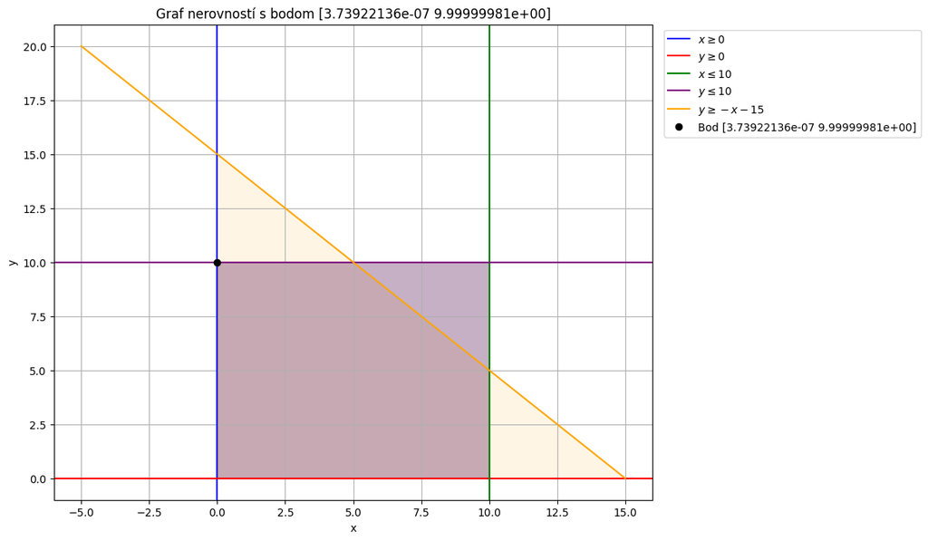

```python
# Definovanie rozsahu hodnôt x a y
x = np.linspace(-5, 15, 400)
y = np.linspace(-5, 15, 400)
X, Y = np.meshgrid(x, y)

# Definovanie bodu z výsledku (predpokladáme, že je to result.x)
point = np.array(result.x)

# Kreslenie nerovností a bodu
plt.figure(figsize=(10, 8))

# Kreslenie prvej nerovnosti (x >= 0)
plt.axvline(x=0, label=r'$x \geq 0$', color='blue')

# Kreslenie druhej nerovnosti (y >= 0)
plt.axhline(y=0, label=r'$y \geq 0$', color='red')

# Kreslenie tretej nerovnosti (x <= 10)
plt.axvline(x=10, label=r'$x \leq 10$', color='green')

# Kreslenie štvrtej nerovnosti (y <= 10)
plt.axhline(y=10, label=r'$y \leq 10$', color='purple')

# Kreslenie piatej nerovnosti (y >= -x - 15)
plt.plot(x, -x + 15, label=r'$y \geq -x - 15$', color='orange')

# Vyplnenie prípustnej oblasti
plt.fill_between(x, -x + 15, 0, where=(x >= 0) & (x <= 15) & (-x - 15 <= 15), color='orange', alpha=0.1)
plt.fill_betweenx(y, 0, 10, where=(y >= 0) & (y <= 10), color='blue', alpha=0.1)
plt.fill_betweenx(y, 0, 10, where=(y >= 0) & (y <= 10), color='red', alpha=0.1)
plt.fill_between(x, 0, 10, where=(x >= 0) & (x <= 10), color='green', alpha=0.1)
plt.fill_between(x, 0, 10, where=(x >= 0) & (x <= 10), color='purple', alpha=0.1)

# Kreslenie bodu result.x
plt.plot(point[0], point[1], 'ko', label=f'Bod {point}')

# Pridanie popisov a nadpisu
plt.xlabel('x')
plt.ylabel('y')
plt.title(f'Graf nerovností s bodom {result.x}')
plt.legend()
plt.legend(bbox_to_anchor=(1.01, 1), loc='upper left')
plt.grid(True)

# Zobrazenie grafu
plt.show()
```

### Záver

Bod minimálnej hodnoty nami zadaného úlohy by mal presne zodpovedať bodu $[0, 10]$. Vypočítané riešenie $[3.73922136e-07, 9.99999981e+00]$ je mierne nepresné vzhľadom na nedokonalosť počítačovej aritmetiky. Avšak tento bod na vykreslenom grafe nie je rozoznateľný od bodu $[0, 10]$.

# **Časť D**

## **Zadanie Časti D**

Algoritmus graficky ilustrujte na vhodne zvolených úlohách s dvoma premennými. Vykreslite prípustný región, vrstevnice $B_{\mu t}(x) = B_{\mu t}(x^*(t))$, „trajektórie“ riešení $x^*(t)$ a optimálne riešenie úlohy. Uvažujte prípad jediného optimálneho riešenia aj prípad s nekonečne veľa optimálnymi riešeniami.

### **Vykreslenie vhodne zvolených úloh**

### **Trajektórie krokov konvergencie**

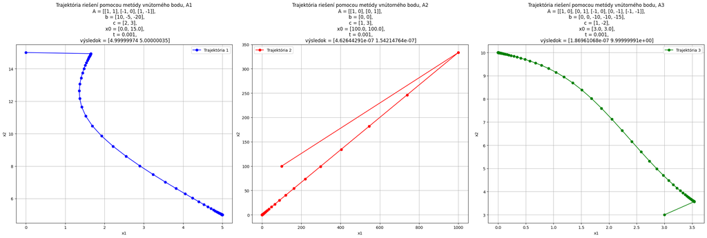

```python
# Zoznamy vstupných parametrov
A_list = [
    [[1, 1], [-1, 0], [1, -1]],
    [[1, 0], [0, 1]],
    [[1, 0], [0, 1], [-1, 0], [0, -1], [-1, -1]]
]
b_list = [
    [10, -5, -20],
    [0, 0],
    [0, 0, -10, -10, -15]
]
c_list = [
    [2, 3],
    [1, 3],
    [1, -2]
]
x0_list = [
    [0.0, 15.0],
    [100.0, 100.0],
    [3.0, 3.0]
]
t_list = [1e-3, 1e-3, 1e-3]
epsilon = 1e-6

# Kreslenie trajektórií

colors = ['blue', 'red', 'green']  # Farby pre jednotlivé trajektórie
fig, axes = plt.subplots(1, 3, figsize=(25, 10))  # Vytvorenie grafu s 3 podgrafmi
for i, ax in enumerate(axes):
    A = np.array(A_list[i])
    b = np.array(b_list[i])
    c = np.array(c_list[i])
    x0 = x0_list[i]
    t = t_list[i]

    result = inner_point_method(A, b, c, t, x0, epsilon)  # Spustenie metódy vnútorného bodu
    trajectory = result.trajectory  # Získanie trajektórie

    ax.plot(trajectory[:, 0], trajectory[:, 1], color=colors[i], marker='o', linestyle='-', label=f'Trajektória {i+1}')  # Kreslenie trajektórie
    ax.set_xlabel('x1')  # Označenie osi x
    ax.set_ylabel('x2')  # Označenie osi y
    ax.set_title(f'Trajektória riešení pomocou metódy vnútorného bodu, A{i+1}\nA = {A_list[i]},\n b = {b_list[i]},\n c = {c_list[i]},\n x0 = {x0},\n t = {t},\n výsledok = {result.x}')  # Nastavenie nadpisu
    ax.legend()  # Zobrazenie legendy
    ax.grid(True)  # Zapnutie mriežky

# Prispôsobenie rozloženia grafu
plt.tight_layout(rect=[0, 0.15, 1, 1])
plt.show()  # Zobrazenie grafu
```

### Záver - trajektórie

Grafy ukazujú, že metóda vnútorného bodu efektívne vedie počiatočné body k optimálnym riešeniam v rámci prípustných oblastí definovaných maticou $A$ a vektorom $b$. Trajektórie ukazujú, ako sa počiatočné body pohybujú v priestore, pričom postupne znižujú hodnotu optimalizačnej funkcie až k nájdeniu optimálneho riešenia. Tento proces je vizualizovaný rôznymi farbami pre každý súbor vstupných parametrov.

### **Vykreslenie vrstevníc**

[figure not shown]

```python
fig, axes = plt.subplots(3, 2, figsize=(15, 15))

linspaces = [[np.linspace(-6, 6, 1201),
              np.linspace(4, 26, 2401),
              np.linspace(4, 5.25, 126),
              np.linspace(4.75, 6, 126)],
             [np.linspace(-1, 26, 1201),
              np.linspace(-1, 26, 1201),
              np.linspace(-0.05, 1, 1201),
              np.linspace(-0.05, 1, 1201)],
             [np.linspace(-1, 11, 1201),
              np.linspace(-1, 11, 1201),
              np.linspace(4.5, 5.5, 1201),
              np.linspace(9.5, 10.5, 1201)]
             ]

for idx in range(len(A_list)):
    A = A_list[idx]
    b = b_list[idx]
    c = c_list[idx]
    x0 = x0_list[idx]
    t = t_list[idx]

    # Prvý graf s prvým súborom hodnôt linspace
    x1 = linspaces[idx][0]
    y1 = linspaces[idx][1]
    X1, Y1 = np.meshgrid(x1, y1)

    matrix_values1 = np.empty(X1.shape)

    for i in range(X1.shape[0]):
        for j in range(X1.shape[1]):
            vector = np.array([X1[i, j], Y1[i, j]])
            if np.all(A @ vector >= b):  # Kontrola prípustnosti
                matrix_values1[i, j] = B_t(vector, A, b, t, c)
            else:
                matrix_values1[i, j] = np.nan  # Neprípustné hodnoty nechceme zobrazovať

    contour1 = axes[idx, 0].contour(X1, Y1, matrix_values1)
    axes[idx, 0].set_title(f"Contour Plot with Linspace (-6, 6, 1201) and (4, 26, 2401) for A[{idx}]")
    axes[idx, 0].set_xlabel('X')
    axes[idx, 0].set_ylabel('Y')
    fig.colorbar(contour1, ax=axes[idx, 0], label='B_t value')

    # Druhý graf s ďalším súborom hodnôt linspace
    x2 = linspaces[idx][2]
    y2 = linspaces[idx][3]
    X2, Y2 = np.meshgrid(x2, y2)

    matrix_values2 = np.empty(X2.shape)

    for i in range(X2.shape[0]):
        for j in range(X2.shape[1]):
            vector = np.array([X2[i, j], Y2[i, j]])
            if np.all(A @ vector >= b):  # Kontrola prípustnosti
                matrix_values2[i, j] = B_t(vector, A, b, t, c)
            else:
                matrix_values2[i, j] = np.nan  # Neprípustné hodnoty nechceme zobrazovať

    contour2 = axes[idx, 1].contour(X2, Y2, matrix_values2)
    axes[idx, 1].set_title(f"Contour Plot with Linspace (4, 5.25, 126) and (4.75, 6, 126) for A[{idx}]")
    axes[idx, 1].set_xlabel('X')
    axes[idx, 1].set_ylabel('Y')
    fig.colorbar(contour2, ax=axes[idx, 1], label='B_t value')

plt.tight_layout()
plt.show()
```

### Záver - vrstevnice

Na základe obrázka, ktorý vychádza z kódu, môžeme pozorovať niekoľko dôležitých bodov pre každý z troch súborov matíc $A$, $b$ a $c$.

Každý riadok obrázka predstavuje jeden súbor vstupných parametrov ($A$, $b$, $c$), pričom prvý graf v riadku ukazuje kontúrový graf funkcie $B_t$ pre širší rozsah hodnôt a druhý graf v riadku zobrazuje užší rozsah hodnôt, aby sme lepšie videli detaily.

Grafy ukazujú, že funkcia $B_t$ sa mení v závislosti od vstupných parametrov ($A$, $b$, $c$) a pozície v rámci prípustnej oblasti. Každý graf nám poskytuje informácie o tom, kde sa môžu nachádzať minimálne hodnoty funkcie a ako sa mení v rámci prípustných hodnôt.

### **Príklad s nekonečne veľa opt. rieš.**

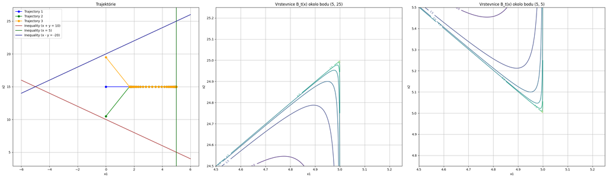

```python
# Matica A, vektor b a vektor c
A = np.array([[1, 1], [-1, 0], [1, -1]])
b = np.array([10, -5, -20])
c = np.array([-1, 0])
x0_list = [[0.0, 15.0], [0.0, 10.5], [0.0, 19.5]]
t = 1e-3
epsilon = 1e-6

# Vypočítanie trajektórií pre všetky počiatočné body
trajectories = []
for i in range(3):
    result = inner_point_method(A, b, c, t, x0_list[i], epsilon)
    trajectories.append(result.trajectory)

# Vytvorenie subplots
fig, (ax1, ax2, ax3) = plt.subplots(1, 3, figsize=(27, 8))

colors = ['blue', 'green', 'orange']

# Prvý subplot - trajektórie a nerovnosti
for i in range(len(x0_list)):
    x0 = x0_list[i]
    trajectory = trajectories[i]
    ax1.plot(trajectory[:, 0], trajectory[:, 1], 'o-', color=colors[i], label=f'Trajectory {i+1}')

# Definícia x pre vykreslenie nerovností
x = np.linspace(-6, 6, 1200)

# Definícia nerovností
ineq1 = 10 - x  # y = 10 - x (pre x + y >= 10)
ineq2 = 5       # x = 5 (pre x <= 5)
ineq3 = x + 20  # y = x + 20 (pre x - y >= -20)

# Plot the inequalities
ax1.plot(x, ineq1, label='Inequality (x + y = 10)', color='brown', linestyle='-')
ax1.axvline(x=ineq2, label='Inequality (x = 5)', color='darkgreen', linestyle='-')
ax1.plot(x, ineq3, label='Inequality (x - y = -20)', color='darkblue', linestyle='-')

# Pridanie popisov a názvu
ax1.set_xlabel('x1')
ax1.set_ylabel('x2')
ax1.set_title('Trajektórie')
ax1.legend()
ax1.grid(True)

# Druhý subplot - vrstevnice funkcie B_t(x)
# Vytvorenie mriežky
dlzka = 1001
x = np.linspace(4.5, 5.25, dlzka)
y = np.linspace(24.5, 25.25, dlzka)
X, Y = np.meshgrid(x, y)

# Predpríprava matice pre hodnoty funkcie B_t(x)
matrix_values = np.empty(X.shape)

# Výpočet hodnôt B_t(x) pre každý bod v mriežke
for i in range(X.shape[0]):
    for j in range(X.shape[1]):
        vector = np.array([X[i, j], Y[i, j]])
        if np.all(A @ vector >= b):  # Kontrola prípustnosti
            matrix_values[i, j] = B_t(vector, A, b, t, c)
        else:
            matrix_values[i, j] = np.nan  # Neprípustné hodnoty nechceme zobrazovať

# Vykreslenie vrstevníc
contour = ax2.contour(X, Y, matrix_values)

# Pridanie popisov vrstevníc
ax2.clabel(contour, inline=True, fontsize=8)

# Pridanie popisov a názvu
ax2.set_xlabel('x1')
ax2.set_ylabel('x2')
ax2.set_title('Vrstevnice B_t(x) okolo bodu (5, 25)')
ax2.grid(True)

dlzka = 1001
x = np.linspace(4.5, 5.25, dlzka)
y = np.linspace(4.75, 5.5, dlzka)
X, Y = np.meshgrid(x, y)

# Predpríprava matice pre hodnoty funkcie B_t(x)
matrix_values = np.empty(X.shape)

# Výpočet hodnôt B_t(x) pre každý bod v mriežke
for i in range(X.shape[0]):
    for j in range(X.shape[1]):
        vector = np.array([X[i, j], Y[i, j]])
        if np.all(A @ vector >= b):  # Kontrola prípustnosti
            matrix_values[i, j] = B_t(vector, A, b, t, c)
        else:
            matrix_values[i, j] = np.nan  # Neprípustné hodnoty nechceme zobrazovať

# Vykreslenie vrstevníc
contour = ax3.contour(X, Y, matrix_values)

# Pridanie popisov vrstevníc
ax3.clabel(contour, inline=True, fontsize=8)

# Pridanie popisov a názvu
ax3.set_xlabel('x1')
ax3.set_ylabel('x2')
ax3.set_title('Vrstevnice B_t(x) okolo bodu (5, 5)')
ax3.grid(True)

# Zobrazenie grafov
plt.tight_layout()
plt.show()
```

### Záver - nekonečne veľa opt. riešení

Prvý graf: Trajektórie a nerovnosti

Trajektórie: Graf zobrazuje trajektórie troch rôznych počiatočných bodov (modrá, zelená a oranžová) počas optimalizácie pomocou metódy vnútorného bodu. Trajektórie ukazujú, ako sa počiatočné body pohybujú smerom k optimálnemu riešeniu. Nerovnosti: Na grafe sú zobrazené aj tri nerovnosti: $x + y \geq 10$ (hnedá čiara) $x \leq 5$ (tmavozelená vertikálna čiara) $x - y \geq -20$ (tmavomodrá čiara)

Tento graf zobrazuje kontúry funkcie $B_t(x)$ pre rozsah hodnôt $x_1$ od 4.5 do 5.25 a $x_2$ od 24.5 do 25.25. Vrstevnice ukazujú, ako sa hodnota funkcie $B_t(x)$ mení v tejto oblasti. Nižšie hodnoty sú zobrazené bližšie k vnútorným oblastiam kontúr.

Tento graf zobrazuje kontúry funkcie $B_t(x)$ pre rozsah hodnôt $x_1$ od 4.5 do 5.25 a $x_2$ od 4.75 do 5.5. Vrstevnice opäť ukazujú, ako sa hodnota funkcie $B_t(x)$ mení v tejto oblasti, pričom nižšie hodnoty sú zobrazené bližšie k vnútorným oblastiam kontúr.

Záver:

Grafy ukazujú, že funkcia $B_t(x)$ sa mení v závislosti od vstupných parametrov ($A$, $b$, $c$) a pozície v rámci prípustnej oblasti. Trajektórie zobrazujú postupný pohyb počiatočných bodov smerom k optimálnemu riešeniu, pričom vrstevnicové grafy poskytujú vizuálne znázornenie hodnôt funkcie $B_t(x)$ v rôznych oblastiach.

Prvý graf ukazuje, že z troch rôznych bodov metóda nájde minimum v jednom bode, konkrétne v strede úsečky $[(5, 5), (5, 25)]$, čo znamená, že metóda našla *nekonečne veľa optimálnych riešení*.

Vrstevnicové grafy ukazujú, že minimum danej funkcie je celá úsečka, pretože vrstevnice sa nachádzajú aj blízko bodu $(5, 5)$ aj $(5, 25)$.

# **Časť E**

## **Zadanie Časti E**

Náhodne generujte úlohy s vopred daným vnútorným bodom $x_0$, t.j. generujte $A$ a $x_0$ a vektor $b$ vhodne dopočítajte. Experimentujte s rôznymi rozmermi a pozorujte rýchlosť konvergencie. Výsledky uveďte v tabuľke, prípadne graficky znázornite (môžete znázorniť $m/t$ v jednotlivých iteráciách).

### **Generovanie problémov**

```python
n,m = 5,2

x0 = np.random.randn(m)

A = np.random.randn(n,m)

b = (A @ x0 - 1)

c = np.random.rand(m)  # Náhodný vektor c

print(x0)
print()
print(A)
print()
print(b)
print()
print(c)
```

```
[-0.19812797 -2.06526401]

[[-1.09253028  0.08857521]
 [ 0.57654929  0.03509103]
 [-1.70260993 -1.10469079]
 [-0.08659613 -1.41303998]
 [ 1.38324839  0.43503039]]

[-0.96647038 -1.18670279  1.61881278  1.93545774 -2.17251281]

[0.7585578  0.62500971]
```

```python
def generate_problem(n, m, epsilon=0.1):
    x0 = np.random.randn(m)
    A = np.random.randn(n,m)
    b = (A @ x0 - 1)
    c = np.random.rand(m)
    return A, b, x0 , c


# Nastavenie parametrov pre rôzne hodnoty n a m
dimensions = [(12, 15), (14, 20), (10, 20)]  # Rôzne (n, m) kombinácie
overall_results = []
t = 1e-3
epsilon = 1e-6

for n, m in dimensions:
    successful_run = False
    while not successful_run:
        try:
            # Generovanie problému a riešenie
            # Vygeneruje problém s danými rozmermi n a m
            A, b, x0, c = generate_problem(n, m)

            # Zaznamená začiatok času riešenia
            start_time = time.time()

            # Rieši problém použitím metódy vnútorného bodu
            result = inner_point_method(A, b, c, t, x0, epsilon)

            # Zaznamená koniec času riešenia
            end_time = time.time()

            # Vypočíta celkový čas riešenia
            final_time = end_time - start_time

            # Zaznamenanie výsledkov
            # Uloží výsledky do zoznamu celkových výsledkov
            overall_results.append({
                'n': n,
                'm': m,
                'results': result.x,
                'times': final_time
            })

            # Nastaví successful_run na True, aby sa ukončil while cyklus pre aktuálne rozmery
            successful_run = True
        except np.linalg.LinAlgError as e:
            # Ak nastane chyba singularity matice, while cyklus pokračuje
            pass

# Vyprintuje celkové výsledky po dokončení všetkých iterácií
print(overall_results)
```

```
[{'n': 12, 'm': 15, 'results': array([ 4.36940623e+71,  3.11313948e+71,  2.32569893e+71,  3.59172672e+71,
       -8.37734910e+71, -2.44952683e+71,  5.92480441e+71,  2.14346339e+71,
        5.59975323e+71, -3.91325918e+71,  3.61630438e+72,  3.36568175e+71,
        1.47034294e+72, -5.54150341e+71,  9.16162229e+71]), 'times': 15.663776159286499}, {'n': 14, 'm': 20, 'results': array([ 3.02193437e+68, -5.89350439e+68,  2.11621862e+67,  9.82799590e+68,
       -1.36466297e+68, -1.07895760e+68,  7.83494324e+67, -4.15757701e+68,
       -5.20932505e+68,  5.67000331e+67, -3.75189110e+68,  1.30461580e+69,
        3.93627481e+68, -9.31091860e+67, -3.98079801e+68, -6.80042947e+68,
       -2.13457884e+67, -6.70856327e+67,  3.05798625e+68,  7.71259866e+67]), 'times': 27.66875410079956}, {'n': 10, 'm': 20, 'results': array([-2.44551047e+85, -1.83859574e+86,  1.50920166e+84,  1.02051844e+85,
       -2.28548874e+84,  7.42692765e+84,  2.48963881e+84, -1.28657148e+84,
       -8.07214407e+84, -4.12420338e+84, -8.35404435e+84,  9.77853957e+84,
        1.31921257e+85,  3.08135123e+84,  6.78724093e+84, -1.29279091e+85,
        6.92724235e+84,  9.19647047e+84,  4.56283707e+85,  4.14656248e+84]), 'times': 20.7136127948761}]
```

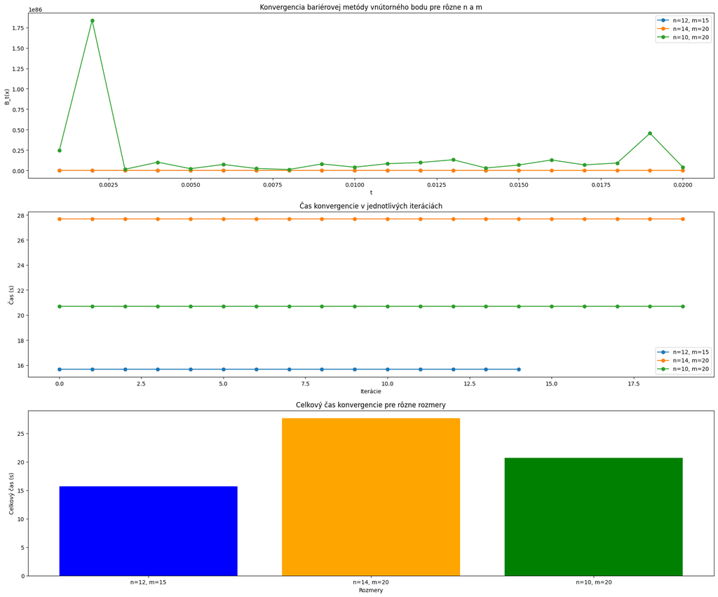

```
Výsledky pre n=12, m=15:
             x0            x1            x2            x3            x4  \
0  4.369406e+71  3.113139e+71  2.325699e+71  3.591727e+71 -8.377349e+71

             x5            x6            x7            x8            x9  \
0 -2.449527e+71  5.924804e+71  2.143463e+71  5.599753e+71 -3.913259e+71

            x10           x11           x12           x13           x14  \
0  3.616304e+72  3.365682e+71  1.470343e+72 -5.541503e+71  9.161622e+71

    Time (s)
0  15.663776


Výsledky pre n=14, m=20:
             x0            x1            x2            x3            x4  \
0  3.021934e+68 -5.893504e+68  2.116219e+67  9.827996e+68 -1.364663e+68

             x5            x6            x7            x8            x9  ...  \
0 -1.078958e+68  7.834943e+67 -4.157577e+68 -5.209325e+68  5.670003e+67  ...

            x11           x12           x13           x14           x15  \
0  1.304616e+69  3.936275e+68 -9.310919e+67 -3.980798e+68 -6.800429e+68

            x16           x17           x18           x19   Time (s)
0 -2.134579e+67 -6.708563e+67  3.057986e+68  7.712599e+67  27.668754

[1 rows x 21 columns]


Výsledky pre n=10, m=20:
             x0            x1            x2            x3            x4  \
0 -2.445510e+85 -1.838596e+86  1.509202e+84  1.020518e+85 -2.285489e+84

             x5            x6            x7            x8            x9  ...  \
0  7.426928e+84  2.489639e+84 -1.286571e+84 -8.072144e+84 -4.124203e+84  ...

            x11           x12           x13           x14           x15  \
0  9.778540e+84  1.319213e+85  3.081351e+84  6.787241e+84 -1.292791e+85

            x16           x17           x18           x19   Time (s)
0  6.927242e+84  9.196470e+84  4.562837e+85  4.146562e+84  20.713613

[1 rows x 21 columns]
```

```python
# Grafické znázornenie výsledkov
plt.figure(figsize=(18, 15))

# Konvergencia bariérovej metódy vnútorného bodu
plt.subplot(3, 1, 1)
for result in overall_results:
    ts = np.linspace(t, t * len(result['results']), len(result['results']))
    B_ts = np.array([np.linalg.norm(r) for r in result['results']])
    plt.plot(ts, B_ts, marker='o', label=f'n={result["n"]}, m={result["m"]}')
plt.xlabel('t')
plt.ylabel('B_t(x)')
plt.title('Konvergencia bariérovej metódy vnútorného bodu pre rôzne n a m')
plt.legend()

# Čas konvergencie v jednotlivých iteráciách pre každý rozmer
plt.subplot(3, 1, 2)
for result in overall_results:
    iterations = range(len(result['results']))
    times = [result['times']] * len(iterations)
    plt.plot(iterations, times, marker='o', label=f'n={result["n"]}, m={result["m"]}')
plt.xlabel('Iterácie')
plt.ylabel('Čas (s)')
plt.title('Čas konvergencie v jednotlivých iteráciách')
plt.legend()

# Celkový čas konvergencie pre rôzne rozmery
total_times = [result['times'] for result in overall_results]
labels = [f'n={result["n"]}, m={result["m"]}' for result in overall_results]

plt.subplot(3, 1, 3)
plt.bar(labels, total_times, color=['blue', 'orange', 'green'])
plt.xlabel('Rozmery')
plt.ylabel('Celkový čas (s)')
plt.title('Celkový čas konvergencie pre rôzne rozmery')

plt.tight_layout()
plt.show()

# Tabuľka výsledkov
import pandas as pd

for result in overall_results:
    if isinstance(result['results'], np.ndarray) and result['results'].ndim > 1:
        df = pd.DataFrame(result['results'], columns=[f'x{i}' for i in range(result['results'].shape[1])])
    else:
        df = pd.DataFrame([result['results']], columns=[f'x{i}' for i in range(len(result['results']))])
    df['Time (s)'] = result['times']
    print(f"Výsledky pre n={result['n']}, m={result['m']}:")
    print(df)
    print("\n")
```

### Záver

#### 3. **Celkový čas konvergencie pre rôzne rozmery (Spodný graf)**

# **Časť F**

## **Zadanie Časti F**

Pomocou algoritmu z časti b) možno určiť, či má daná úloha vnútorný bod. Na to stačí riešiť úlohu:

$$ \min t $$

podmienky:

$$ Ax - b \geq (1 - t) 1, $$

$$ t \geq 0. $$

Zdôvodnite. Implementujte kód, pomocou ktorého zistíme, či má úloha v tvare vnútorný bod a ak áno, nájdeme jej riešenie metódou vnútorného bodu.

### **Implementácia**

```python
def has_interior_point(A, b, c, t,x0):
    m, n = A.shape

    # Pridáme ďalšiu premennú t do matice A a vektora c
    c = np.zeros(n + 1)
    c[-1] = 1  # minimalizujeme t

    # Pridáme obmedzenia Ax - b >= (1 - t)1
    A_ub = np.hstack((A, np.ones((m, 1))))
    b_ub = b - np.ones(m)


    # Počiatočný bod (vhodný inicializačný bod)
    x0 = [1,1,1e-3]

    # Parameter t0 a epsilon
    epsilon = 1e-6

    # Riešime pomocou vlastnej implementácie inner_point_method
    res = inner_point_method(A_ub, b_ub, c, t, x0, epsilon)

    if res.success and res.x[-1] < 1:
        return True, res.x[:-1]  # vnútorný bod existuje a vrátime ho (bez posledného prvku, ktorý je t)
    else:
        return False, None  # vnútorný bod neexistuje

A = np.array([
    [1, 0],
    [0, 1],
    [-1, 0],
     [0, -1]
])
b = np.array([0, 0, -3, -3])

x0 = [5., 5.]  # Východiskový bod
t = 1e-3  # Parameter t
epsilon = 1e-6  # Tolerancia epsilon


has_interior, point = has_interior_point(A, b, c, t, x0)
if has_interior:
    print("Úloha má vnútorný bod:", point)
else:
    print("Úloha nemá vnútorný bod.")
```

```
Úloha má vnútorný bod: [1.5 1.5]
```

### **Vizualizácia implementácie**

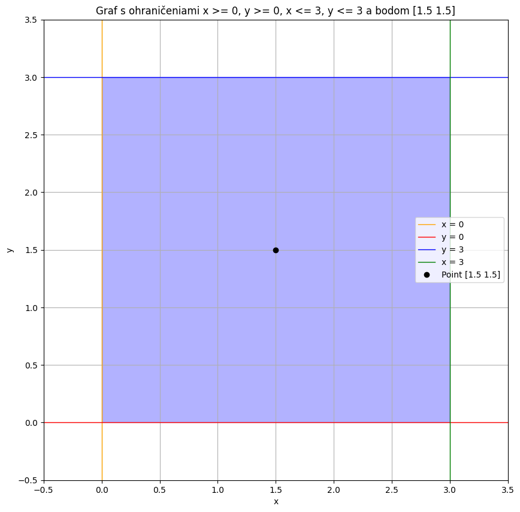

```python
# Vytvorenie grafu
plt.figure(figsize=(10, 10))

# Kreslenie obmedzení pomocou zvislých a vodorovných čiar
plt.axvline(x=0, color='orange', linestyle='-', linewidth=1, label='x = 0')
plt.axhline(y=0, color='red', linestyle='-', linewidth=1, label='y = 0')
plt.axhline(y=3, color='blue', linestyle='-', linewidth=1, label='y = 3')
plt.axvline(x=3, color='green', linestyle='-', linewidth=1, label='x = 3')

# Zvýraznenie prípustnej oblasti
x_vals = np.linspace(0, 3, 400)
y_vals = np.linspace(0, 3, 400)
X, Y = np.meshgrid(x_vals, y_vals)
plt.fill_between(x_vals, 0, 3, where=(x_vals <= 3), color='blue', alpha=0.3)

# Kreslenie bodu
plt.plot(point[0], point[1], 'ko', label=f'Point {point}')

# Nastavenie limitov a popisov
plt.xlim(-0.5, 3.5)
plt.ylim(-0.5, 3.5)
plt.xlabel('x')
plt.ylabel('y')
plt.title(f'Graf s ohraničeniami x >= 0, y >= 0, x <= 3, y <= 3 a bodom {point}')
plt.legend()
plt.grid(True)
plt.show()
```

### **Slovný opis riešenia**

#### Zdôvodnenie

Ak úloha $ \min c^T x $ s obmedzeniami $ Ax \geq b $ má vnútorný bod, znamená to, že existuje $ x $ také, že $ Ax > b $.

Úloha $ \min t $ s obmedzeniami $ Ax - b \geq (1 - t)\mathbf{1} $ a $ t \geq 0 $ je ekvivalentná nasledovnému:

- Ak existuje $ x $ a $ t \geq 0 $, pre ktoré $ Ax - b \geq (1 - t)\mathbf{1} $, potom môžeme zistiť, či úloha $ Ax \geq b $ má vnútorný bod.
- Ak optimálna hodnota $ t $ je menšia ako 1, znamená to, že existuje $ x $, pre ktoré $ Ax > b $, a teda $ x $ je vnútorný bod.

#### Implementácia

1. Funkcia `has_interior_point` prijíma maticu $ A $ a vektor $ b $.
2. Definuje objektívnu funkciu, ktorá minimalizuje $ t $.
3. Definuje obmedzenia, ktoré zabezpečujú, že $ Ax - b \geq (1 - t)\mathbf{1} $.
4. Vytvára počiatočný bod $ x0 $ a nastavuje obmedzenia pre premenné, kde $ t \geq 0 $.
5. Používa funkciu `inner_point_method` na riešenie optimalizačného problému.
6. Ak je výsledok úspešný a optimálna hodnota $ t $ je menšia ako 1, úloha má vnútorný bod.

# **Časť G**

## **Zadanie Časti G**

**Nadstavba:** Vymyslite rozšírenie projektu. Vedeli by ste napríklad testovať prípustnosť a neohraničenosť úlohy, prípadne riešiť úlohu s ohraničeniami v tvare rovnosti?

### **Neohraničenosť úlohy**

```python
def newton_trajectory(jac, hess, x0=None, args=(), callback=None, options={}, **kwargs):
    # Ak nie je poskytnutý počiatočný odhad `x0`, vyhodí sa chyba
    if x0 is None:
        raise ValueError("Musíte poskytnúť počiatočný odhad `x0`!")

    # Získanie maximálneho počtu iterácií a tolerancie z parametrov (alebo použitie predvolených hodnôt)
    maxiter = options.get("maxiter", 1000)
    tol = options.get("tol", 1e-3)

    # Inicializácia počiatočného bodu, počtu vyhodnotení funkcie gradientu a trajektórie
    x = np.array(x0)
    njev = 0
    trajectory = [x.copy()]

    # Hlavný cyklus Newtonovej metódy
    for it in range(1, maxiter+1):
        try:
            # Výpočet gradientu v aktuálnom bode
            grad = jac(x, *args)
            njev += 1

            # Výpočet Hesienovej matice v aktuálnom bode
            hessian = hess(x, args[0], args[1])

            # Výpočet kroku delta_x riešením lineárneho systému
            delta_x = np.linalg.solve(hessian, -grad)
            njev += 1

            # Aktualizácia aktuálneho bodu
            x += delta_x
            trajectory.append(x.copy())

            # Kontrola konvergencie: ak je norma kroku menšia ako tolerancia, ukončí sa cyklus
            if np.sqrt(delta_x.T @ hessian @ delta_x) < tol:
                break

            # Ak je poskytnutá spätná väzba, zavolá sa s aktuálnym bodom
            if callback is not None:
                callback(x)

        except np.linalg.LinAlgError as e:
            if 'Singular matrix' in str(e):
                print("Úloha nemá optimálne riešenie. :-/")
                break

    # Skontrolovanie úspešnosti optimalizácie
    success = np.sqrt(delta_x.T @ hessian @ delta_x) < tol
    njev += 1

    # Správa o úspechu alebo neúspechu optimalizácie
    if success:
        msg = "Optimalizácia bola úspešná"
    else:
        msg = "Optimalizácia zlyhala"

    # Vrátenie výsledku optimalizácie v štruktúre OptimizeResult
    return OptimizeResult(x=x, success=success, message=msg, jac=grad, nit=it, njev=njev, nhev=it, trajectory=trajectory)
```

```python
A = np.array([[5, 4], [23, 8], [0, 7]])
b = np.array([4, 2, 0])
c = np.array([1, -1])
x0 = [2., 2.]
t = 1e-3

result = newton_trajectory(jac=gradient_vector, hess=hessian_matrix, x0=x0, args=(A, b, t, c))

# Výpis výsledku optimalizácie
print("Optimization result:")
print("x =", result.x)
print("Success:", result.success)
print("Message:", result.message)
print("Nit:", result.nit)
print("Njev:", result.njev)
print("Trajektória:", result.trajectory)
```

[output not shown]

### **Implementácia**

```
Úloha nemá optimálne riešenie. :-/
```

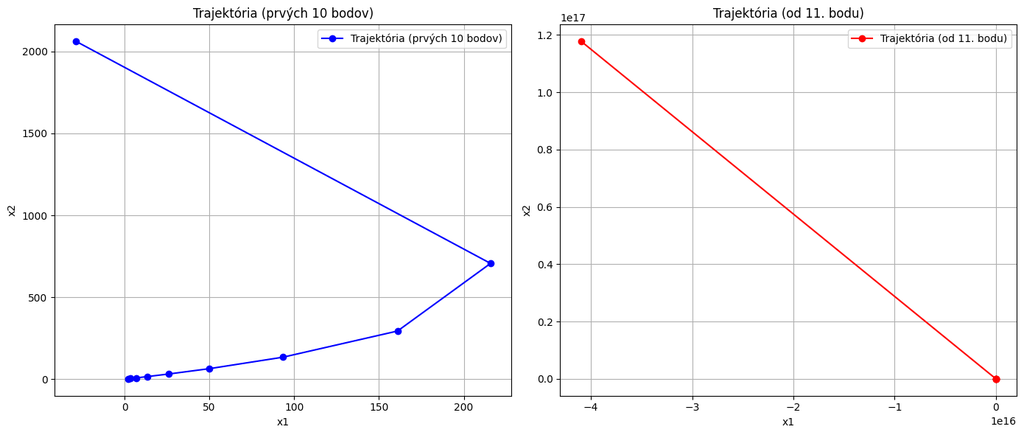

```python
A = np.array([[5, 4], [23, 8], [0, 7]])
b = np.array([4, 2, 0])
c = np.array([1, -1])
x0 = [2., 2.]
t = 1e-3

result = newton_trajectory(jac=gradient_vector, hess=hessian_matrix, x0=x0, args=(A, b, t, c))

trajectory = result.trajectory # Získanie trajektórie a konvertovanie na numpy pole
traj_part1 = trajectory[:10]
traj_part2 = trajectory[10:]

# Vytvorenie dvoch grafov
fig, (ax1, ax2) = plt.subplots(1, 2, figsize=(14, 6))

# Prvý graf (trajektória prvých 10 bodov)
ax1.plot([point[0] for point in traj_part1], [point[1] for point in traj_part1], color='b', marker='o', linestyle='-', label='Trajektória (prvých 10 bodov)')
ax1.set_xlabel('x1')
ax1.set_ylabel('x2')
ax1.set_title('Trajektória (prvých 10 bodov)')
ax1.legend()
ax1.grid(True)

# Druhý graf (trajektória od 11. bodu)
ax2.plot([point[0] for point in traj_part2], [point[1] for point in traj_part2], color='r', marker='o', linestyle='-', label='Trajektória (od 11. bodu)')
ax2.set_xlabel('x1')
ax2.set_ylabel('x2')
ax2.set_title('Trajektória (od 11. bodu)')
ax2.legend()
ax2.grid(True)

# Prispôsobenie rozloženia grafu
plt.tight_layout()

# Zobrazenie grafov
plt.show()
```

### **Záver**

Rozhodli sme sa testovať neohraničenosť úlohy. Pri analýze trajektórie bodov pozorujeme, že sa body postupne vzďaľujú s každým ďalším krokom. Toto je spôsobené prudkým nárastom hodnôt, čo indikuje, že funkcia, ktorá tieto body popisuje, je neohraničená.

#### **Záver:** Na základe uvedených grafov a analýzy bodov môžeme konštatovať, že skúmaná funkcia je neohraničená a rýchlo diverguje. Tento záver je podporený rýchlym nárastom hodnôt bodov, ktoré sme pozorovali.